# Densidade de políticas para mulheres e ideologias político-partidárias

[figure not shown]

Uma análise da densidade de políticas públicas para mulheres associada às ideologias político-partidárias

**Bruna Gomes Guimarães**  
Mestranda em Ciência Política – IPOL/UnB  
Orientador: **Prof. Frederico Bertholini**

Apresentação do andamento da pesquisa · novembro de 2026

## Pergunta e problema de pesquisa

**Pergunta:** em que medida as ideologias político-partidárias no Brasil estão associadas à variação na **densidade** do subsistema de políticas públicas para mulheres?

### Problema

- Diante da ascensão de governos populistas e neoconservadores de direita, a literatura documenta reação e esvaziamento das pautas e estruturas estatais de igualdade de gênero (*backsliding*, política antigênero).
- No Brasil, esse subsistema é composto por organismos, conselhos, planos e serviços em estados e municípios – e convive com ciclos de expansão e retração.
- Será que essas variações acompanham a orientação ideológica de quem governa?

## Conceitos teóricos, lacuna e contribuição

- **Policy dismantling** (Bauer e Knill, 2012): corte ou enfraquecimento de políticas; aplico apenas o aspecto da **densidade** (nº de estrutura, políticas e instrumentos) .
- **Policy backsliding** e **Política antigênero** (Krizsán et al., 2026; Roggeband e Krizsán, 2018)
- **Ideologia político-partidária**: escala de Bolognesi, Ribeiro e Codato (2023) PSL, PRTB, Podemos, Novo PL como ultradireita Borges e Zanotti (2024),Borges (2023), Rennó (2023), Talita Tanscheit e Lisa Zanotti (2023) Chapel Hill Expert Survey (CHES) .* - *minha dúvida se posso fazer isso?* EX: DEM é extrema-direita para Bolognesi

**Lacuna**  
Inicialmente a literatura de desmantelamento aponta como motivações: a crise fiscal e a austeridade (Pierson, 1994; Bauer et al., 2012). No entanto, a partir da ascensão ao poder da ultradireita em diversos países, o papel da ideologia política ganhou destaque (Lopreite, 2013; Zbyszewska, 2017; Krizsán; Roggeband, 2018; Krizsán; Popa, 2018; Roggeband; Krizsán, 2020; Daverio, 2023) e no Brasil, ainda é pouco testada com dados longitudinais estaduais e municipais (Carlos et. al.,2025).

**Contribuição**  
Medir a densidade do subsistema nos níveis **municipal e estadual** (2013–2023) e testar sua associação com a orientação ideológico-partidária dos governos.

## Hipóteses e objetivos

**H1 (geral):** a densidade das políticas públicas para mulheres associa-se negativamente à força da direita político-partidária e do bolsonarismo nos estados.  
**H1a (gov municipal):** estados com maior proporção de prefeitos de direita apresentam menor densidade e menor expansão das estruturas municipais (MUNIC).  
**H1b (gov estadual):** estados governados por partidos de direita apresentam menor expansão ou maior retração das estruturas e da rede estadual de políticas para mulheres (ESTADIC)  
**H1c(apoio eleitoral):** quanto maior a força eleitoral de Bolsonaro no estado (% de municípios em que venceu no 1º turno de 2018 e 2022), maior a probabilidade de retração ou de menor expansão da densidade.  
**H0:** não há associação identificável entre a orientação ideológico-partidária e a variação da densidade.

**Objetivo geral:** analisar a associação entre a orientação ideológico-partidária dos governos (federal, estaduais e municipais) e a densidade do subsistema de políticas para mulheres em 2013, 2018 e 2023.

**Objetivos específicos**

1. Construir um banco longitudinal estado-ano reunindo dados da MUNIC (agregada por estado) e da ESTADIC (governo estadual).
2. Classificar a ideologia de presidentes, governadores e prefeitos e medir o apoio a Bolsonaro(% votos) e identificar a variáção ideológica.
3. Descrever expansão, estagnação e retração do subsistema e associá-las às mudanças de governo.

## O banco de dados

**78 observações** = 26 UFs × 3 períodos (2013, 2018, 2023) · fontes: MUNIC e ESTADIC/IBGE, TSE, Bolognesi, Ribeiro e Codato (2023), Projeções da População/IBGE

scripts `01` → `05`: **df_final** (completo, todas as etapas de cálculo) → **df_analise** (descritivas) → script `06`: **df_munic** e **df_estadic** (modelos)

| **df_munic** | hipóteses H1a e H1c |
| --- | --- |
| **Y** | `densidade`, `d_densidade`, `ret_densidade`; componentes `tx_opm`, `tx_cmdm`, `tx_plano`; `densidade_serv`, `hier_opm` |
| **X** | `pref_dir`, `d_pref_dir` (% de prefeitos CD + D + UD); `gov_dir`; `voto_bolso`, `voto_bolso_ant` |
| **Controle** | `tx_100k` (% de municípios com +100 mil hab.) |

| **df_estadic** | hipóteses H1b e H1c |
| --- | --- |
| **Y** | `rede_est` (8 serviços por 100 mil mulheres), `log_rede`, `d_rede_est`, `traj_rede`, `ret_rede`; `opm_est`, `pem_est`, `cedm_p_est` |
| **X** | `gov_dir` (governador de direita = 1), `troca_gov`; `voto_bolso`, `voto_bolso_ant` |
| **Controle** | `tx_100k` |

Normalização: contagens em taxas (% de municípios; por 100 mil mulheres), rede em log, coeficientes também em escore z.

## Passo a passo metodológico

1**Bancos**  
Taxas, índices e trajetórias; `df_munic` e `df_estadic`

2**Descritiva**  
Medianas, CV, assimetria, Q-Q, trajetórias, mapas, *outliers*

3**Bivariados**  
Teste escolhido pelo nível de mensuração; I de Moran

4**Painel**  
POLS, efeitos fixos, efeitos aleatórios, primeiras diferenças; Hausman

5**Diagnósticos e robustez**  
Erros CR2, VIF, Wooldridge, Cook, sensibilidade

**Desenho**

- Quantitativo, longitudinal, observacional
- Inferência **associativa**, não causal (King, Keohane e Verba, 1994)
- Painel curto: N = 26 UFs, T = 3 períodos
- Cada etapa é lida à luz da anterior

**Y**

- **MUNIC** → densidade das estruturas municipais (H1a)
- **ESTADIC** → rede de atendimento do governo estadual (H1b)
- **Voto em Bolsonaro** → variação 2018–2023 nos dois níveis (H1c)
- Presidente = contexto, absorvido pelas dummies de ano

## Etapa 3: testes bivariados

(Cervi, 2017; 2019)

| Teste | Pergunta | Variáveis | Leitura |
| --- | --- | --- | --- |
| **Spearman** | Quanto mais X, menos Y? | `pref_dir` × `densidade`; `d_pref_dir` × `d_densidade`; `voto_bolso_ant` × `d_densidade` | −1 a +1 |
| **Correlação parcial** | A relação resiste ao porte? | as mesmas, controlando `tx_100k` | compara com a original |
| **Mann-Whitney** | Os grupos diferem? | `rede_est` × `gov_dir` | medianas e valor-p |
| **Gama** | Uma ordem acompanha a outra? | `opm_est` × `gov_dir` | −1 a +1 |
| **Qui-quadrado / Fisher** | A proporção muda entre grupos? | `pem_est`, `cedm_p_est` × `gov_dir` | proporções e valor-p |
| **Resíduos padronizados** | Onde está a associação? | `traj_rede` × `troca_gov` | acima de ±1,96 |

**Resíduos pelo porte:** densidade esperada dado `tx_100k` → quais UFs ficam acima ou abaixo do esperado, e qual a ideologia delas?

**I de Moran:** vizinhos têm densidades parecidas? Se sim, parte da associação pode ser regional → reforça os efeitos fixos de estado.

## Etapa 4: modelos de painel

y<sub>it</sub> = β·x<sub>it</sub> + γ·z<sub>it</sub> + ν<sub>t</sub> + c<sub>i</sub> + u<sub>it</sub>

x = ideologia · z = controles · ν<sub>t</sub> = dummies de ano · c<sub>i</sub> = efeito do estado (tudo o que é estável e não observado) · u = erro

**POLS** (MQO empilhado)  
Variação entre e dentro das UFs. Supõe c<sub>i</sub> sem relação com X. *Linha de base.*

**Efeitos fixos (FE)**  
Subtrai a média de cada UF: usa só a variação **dentro** do estado. Válido mesmo se c<sub>i</sub> se relaciona com a ideologia. *Modelo principal.*

**Efeitos aleatórios (RE)**  
Mais eficiente se c<sub>i</sub> não se relaciona com X. Equivale ao **multinível** com intercepto aleatório por UF.

**Primeiras diferenças (FD)**  
Variação de Y contra variação de X entre períodos. *Robustez.*

- **Hausman** (FE × RE): p < 0,05 → c<sub>i</sub> se relaciona com a ideologia → preferir FE
- **Por que comparar POLS e FE?** Spearman `pref_dir` × `densidade` = −0,44 a −0,59 no **nível**, mas ≈ −0,06 na **variação**. Se o FE não confirmar, a ideologia acompanha o **padrão estrutural** de cada estado, e não mudanças de curto prazo.

## Etapa 4: H1c e erros-padrão

### H1c – apoio eleitoral

- `voto_bolso` 2018 e 2022
- Y = variação **2018 → 2023**; X = voto de **2018** (`voto_bolso_ant`), que antecede a variação
- Equivale a primeiras diferenças com T = 2 (26 UFs)
- `d_densidade` e `d_rede_est` por MQO
- Retração (`ret_densidade` = 1) por **modelo linear de probabilidade**: a logística é instável com 26 casos

### Erros-padrão agrupados (cluster) por UF

- Cada UF aparece 3 vezes → erros do mesmo estado se correlacionam (**correlação serial**) e a variância muda entre estados (**heterocedasticidade**)
- O cluster por UF corrige os dois de uma vez
- Só 26 grupos → correção para amostras pequenas **CR2** + graus de liberdade de Satterthwaite (`clubSandwich`)

## Etapa 5: diagnósticos e robustez

### Diagnósticos

| Problema | Teste | Leitura |
| --- | --- | --- |
| Colinearidade | VIF | > 5 merece atenção |
| Heterocedasticidade | Breusch-Pagan | CR2 já corrige |
| Correlação serial | Wooldridge (FE) | pouco poder com T = 3 |
| Casos influentes | Distância de Cook | > 4/n (PR, MT, BA) |
| Normalidade | Shapiro-Wilk, Q-Q | importa com n pequeno |

### Robustez e sensibilidade

- Componentes da densidade em separado
- X alternativo: `pref_ud`; 7 espectros do governador
- Gestões anteriores: prefeitos de 2008 (2013) e governadores de 2018 (2023)
- União Brasil centro-direita ou direita (?) DEM+PSL em 2022 (muitos prefeitos eleitos em 2023 altera)
- Sem *outliers* e sem RO 2023 (recusa)
- `voto_bolso` como controle em H1a e H1b

## Síntese: hipóteses, variáveis e testes

| Hipótese | Y | X | Testes e modelos |
| --- | --- | --- | --- |
| **H1a** – governos municipais | `densidade`, `d_densidade`, componentes | `pref_dir`, `d_pref_dir` | Spearman, correlação parcial, POLS, FE, RE, FD, Hausman |
| **H1b** – governo estadual | `log_rede`, `d_rede_est`, `traj_rede`, `opm_est`, `pem_est`, `cedm_p_est` | `gov_dir`, `troca_gov` | Mann-Whitney, Gama, Fisher, resíduos padronizados, POLS, FE, RE |
| **H1c** – apoio eleitoral | `d_densidade`, `ret_densidade`, `d_rede_est` | `voto_bolso_ant` | Spearman, MQO e modelo linear de probabilidade (2018 → 2023) |

## Análises descritivas: munic

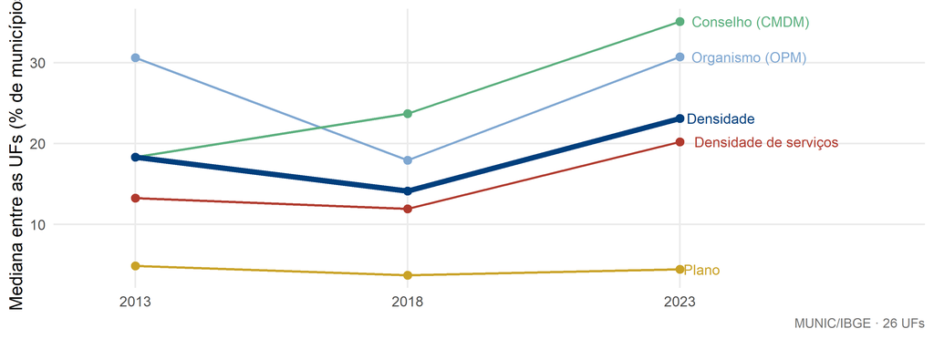

**Técnicas e variáveis**

- Boxplots e medianas por período: `densidade` e componentes (`tx_*`)
- Trajetórias: `traj_opm`, `traj_cmdm`, `traj_plano`, `traj_rede`, `traj_hier`
- Densidade × porte (`tx_100k`) e resíduos por UF
- Densidade por espectro do governador (`gov_id`, `gov_esp`) e por % de prefeitos de ultradireita (`pref_ud`)
- Variação da agenda (`d_agenda`) e da hierarquia (`h_opm`)
- **Próximos testes** (Cervi, 2017; 2019): Spearman, Gama, Q de Yule, resíduos padronizados, I de Moran

## ESTADIC: evolução da rede de atendimento

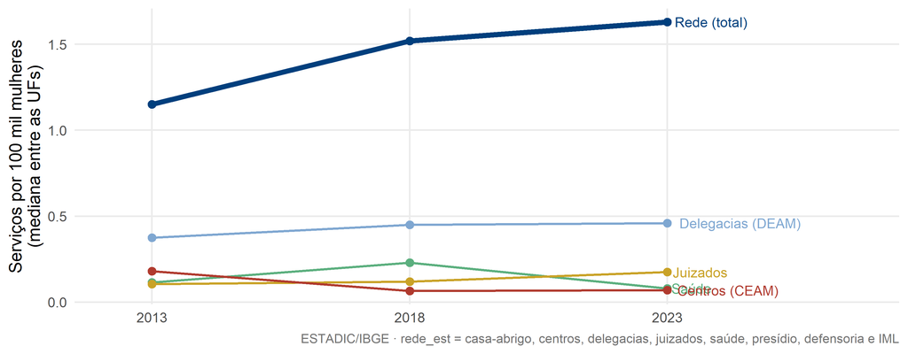

Mediana da rede estadual: 1,1 (2013), 1,5 (2018) e 1,6 (2023) serviços por 100 mil mulheres. Mediana da variação: 14,9% em 2013→2018 e 5,9% em 2018→2023.

## ESTADIC: rede e espectro do governador

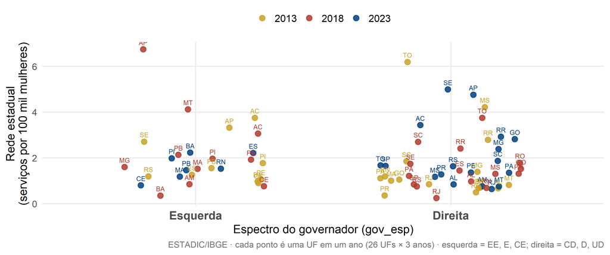

Pontos com governador de esquerda: 28; de direita: 49. Mediana da rede: 1,6 (esquerda) e 1,3 (direita) serviços por 100 mil mulheres. Leitura descritiva: estados pequenos tendem a ter taxas maiores.

## MUNIC: casos contrastantes

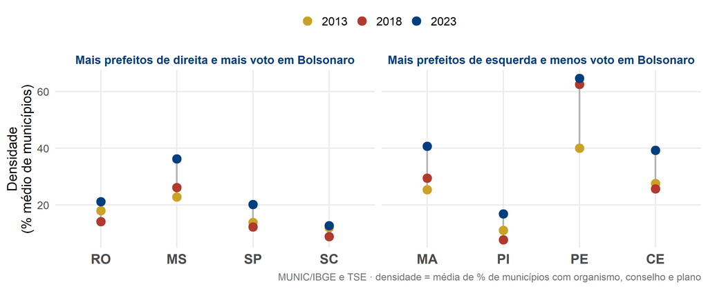

Critério de seleção (pelo perfil político, não pelo resultado): estados com a maior e a menor presença de prefeitos de direita (CD, D, UD) e de municípios em que Bolsonaro venceu no 1º turno (2018 e 2022). Casos ilustrativos: o grupo da esquerda é todo do Nordeste, e a região também pode explicar parte da diferença.